# Rqc 1.36.0 - Quality Control Report

# Rqc 1.36.0 - Quality Control Report

## File Information

This table describes input files. `reads` column can be total number of reads (`sample=FALSE`) or sample size.

```r
kable(perFileInformation(rqcResultSet))
```

| filename | pair | format | group | reads | total.reads | path |
| --- | --- | --- | --- | --- | --- | --- |
| SRR1552444.fastq.gz | 1 | FASTQ | None | 1000 | 1000 | fastq |
| SRR1552445.fastq.gz | 2 | FASTQ | None | 1000 | 1000 | fastq |
| SRR1552446.fastq.gz | 3 | FASTQ | None | 1000 | 1000 | fastq |
| SRR1552447.fastq.gz | 4 | FASTQ | None | 1000 | 1000 | fastq |
| SRR1552448.fastq.gz | 5 | FASTQ | None | 1000 | 1000 | fastq |
| SRR1552449.fastq.gz | 6 | FASTQ | None | 1000 | 1000 | fastq |
| SRR1552450.fastq.gz | 7 | FASTQ | None | 1000 | 1000 | fastq |
| SRR1552451.fastq.gz | 8 | FASTQ | None | 1000 | 1000 | fastq |
| SRR1552452.fastq.gz | 9 | FASTQ | None | 1000 | 1000 | fastq |
| SRR1552453.fastq.gz | 10 | FASTQ | None | 1000 | 1000 | fastq |
| SRR1552454.fastq.gz | 11 | FASTQ | None | 1000 | 1000 | fastq |
| SRR1552455.fastq.gz | 12 | FASTQ | None | 1000 | 1000 | fastq |

## Per Read Mean Quality Distribution of Files

This plot describe an overview of per read mean quality distribution of all files

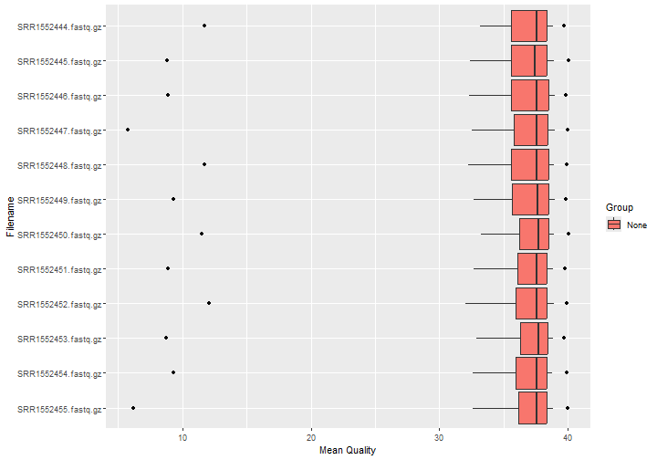

```r
rqcReadQualityBoxPlot(rqcResultSet)
```

## Average Quality

This plot describes the average quality pattern by showing on the X-axis quality thresholds and on the Y-axis the percentage of reads that exceed that quality level.

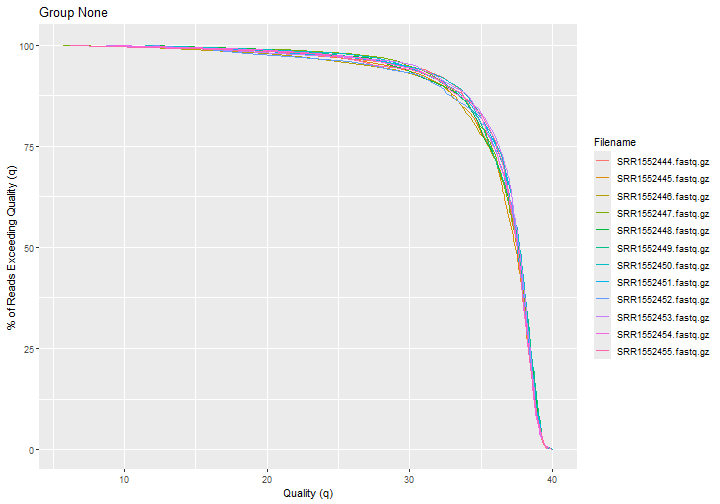

```r
groups <- unique(perFileInformation(rqcResultSet)$group)
for (group in groups) {
  rqcResultSet.sub <- subsetByGroup(rqcResultSet, group)
  print(rqcReadQualityPlot(rqcResultSet.sub) +
          ggtitle(paste("Group", group)))
}
```

## Cycle-specific Average Quality

This plot describes the average quality scores for each cycle of sequencing.

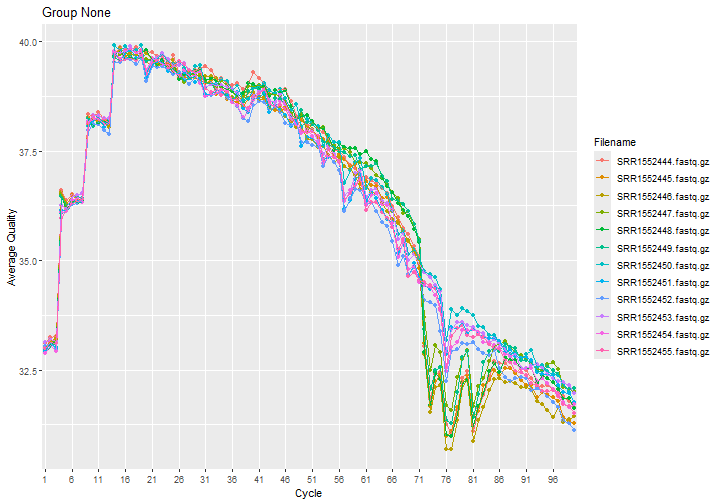

```r
for (group in groups) {
  rqcResultSet.sub <- subsetByGroup(rqcResultSet, group)
  print(rqcCycleAverageQualityPlot(rqcResultSet.sub) +
          ggtitle(paste("Group", group)))
}
```

## PCA Biplot (cycle-specific read average quality)

Biplot from Principal Component Analysis (PCA) of cycle-specific read average quality.

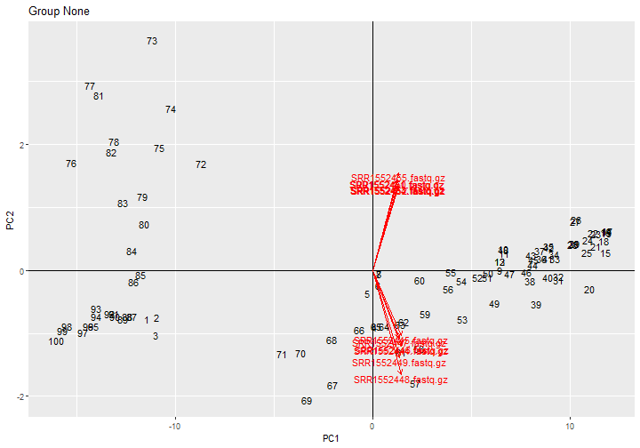

```r
for (group in groups) {
  rqcResultSet.sub <- subsetByGroup(rqcResultSet, group)
  print(rqcCycleAverageQualityPcaPlot(rqcResultSet.sub) +
          ggtitle(paste("Group", group)))
}
```

## Read Frequency

This plot shows the proportion of reads that appeared many times.

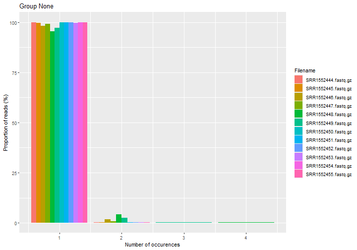

```r
for (group in groups) {
  rqcResultSet.sub <- subsetByGroup(rqcResultSet, group)
  print(rqcReadFrequencyPlot(rqcResultSet.sub) +
          ggtitle(paste("Group", group)))
}
```

## Read Length Distribution

Barplot that presents the distribuition of the lengths of the reads available in the FASTQ file.

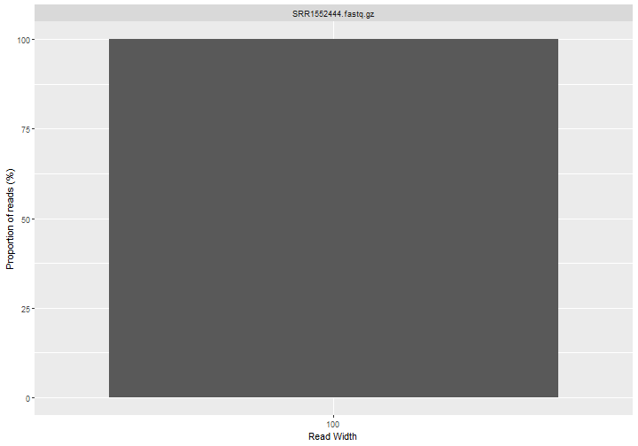

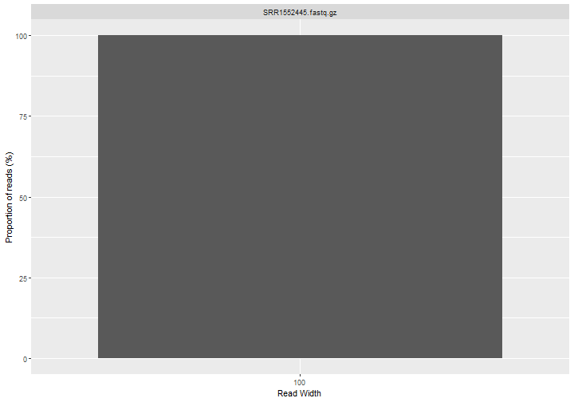

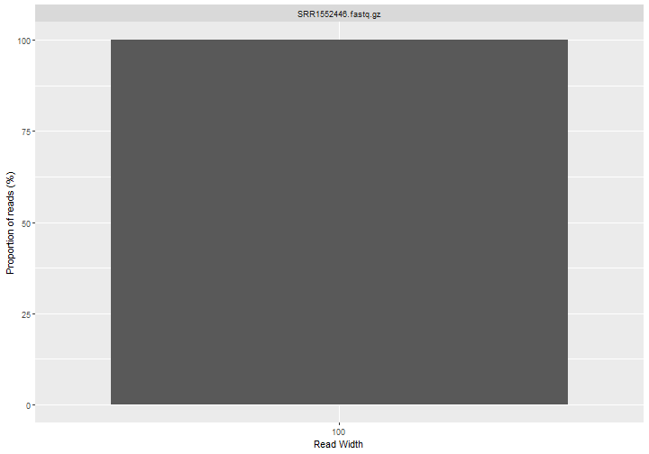

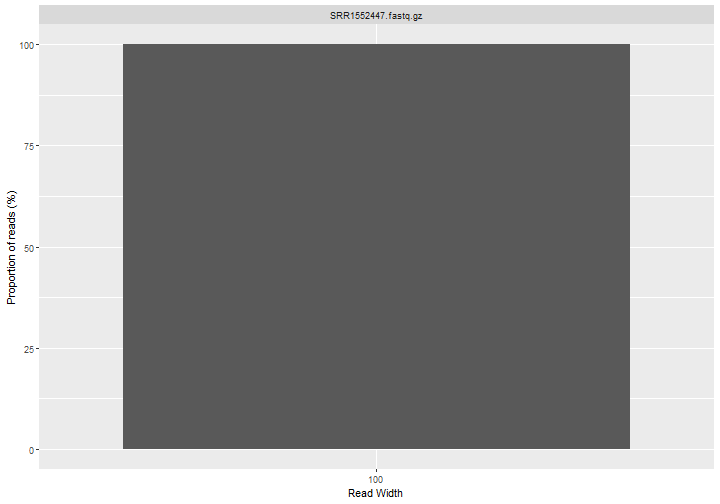

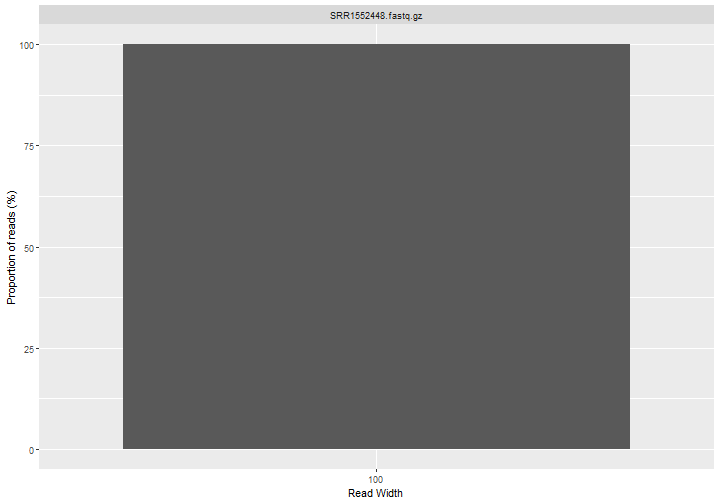

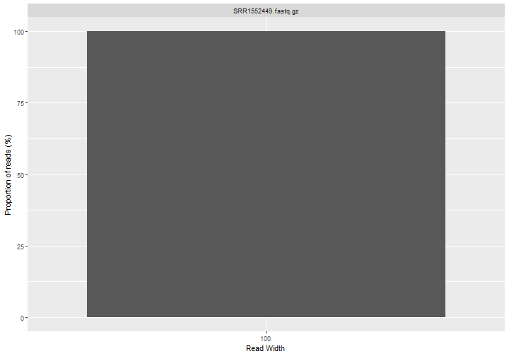

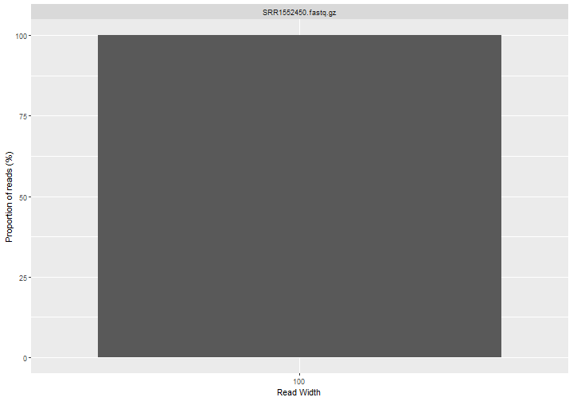

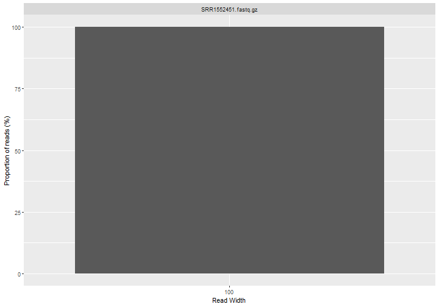

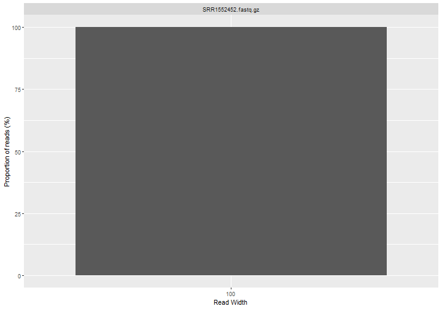

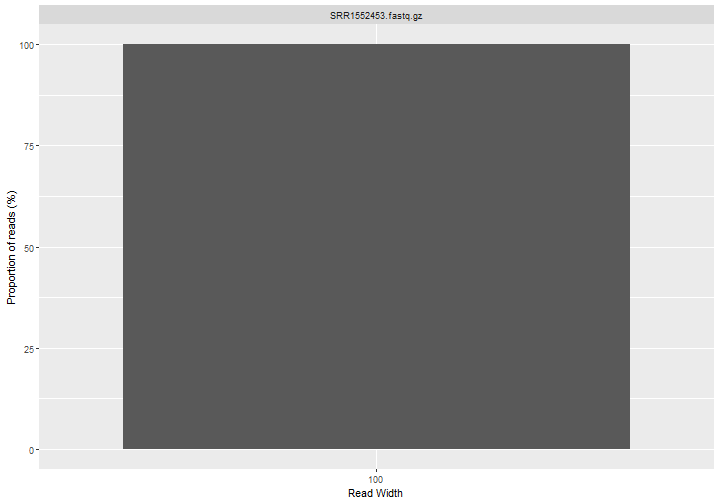

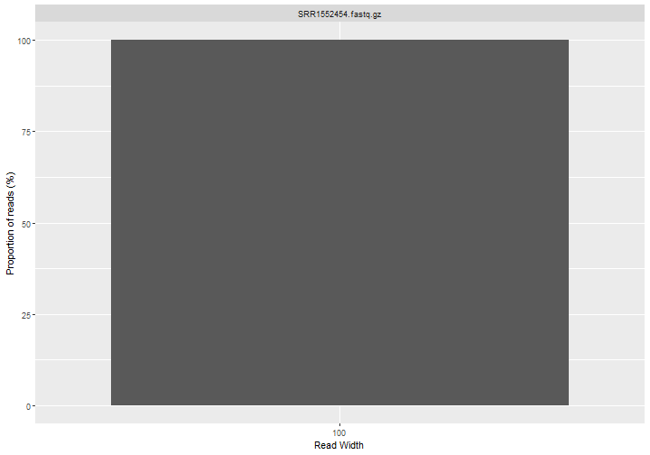

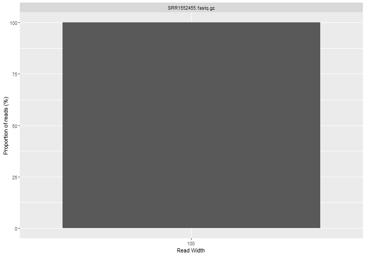

```r
pairs <- unique(perFileInformation(rqcResultSet)$pair)
for(pair in pairs) {
  rqcResultSet.sub <- subsetByPair(rqcResultSet, pair)
  print(rqcReadWidthPlot(rqcResultSet.sub))
}
```

## Cycle-specific GC Content

Line plot showing the average GC content for every cycle of sequencing.

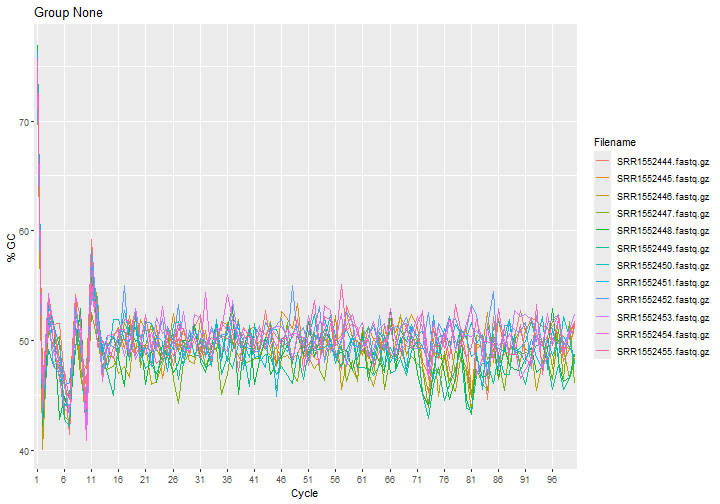

```r
for (group in groups) {
  rqcResultSet.sub <- subsetByGroup(rqcResultSet, group)
  print(rqcCycleGCPlot(rqcResultSet.sub) +
          ggtitle(paste("Group", group)))
}
```

## Cycle-specific Quality Distribution

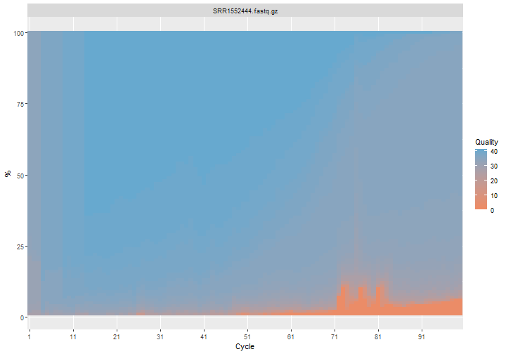

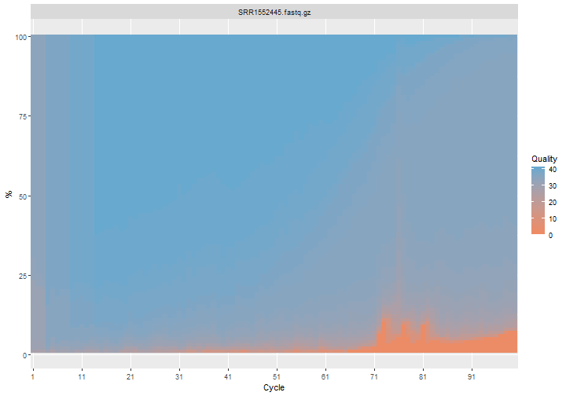

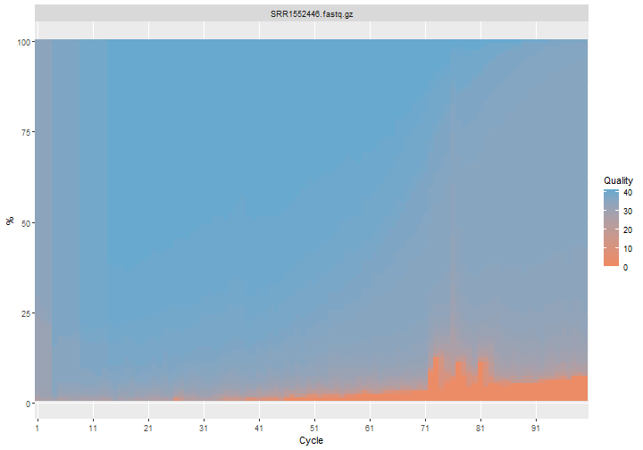

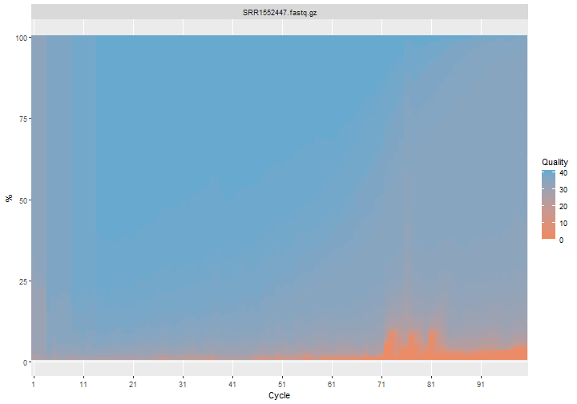

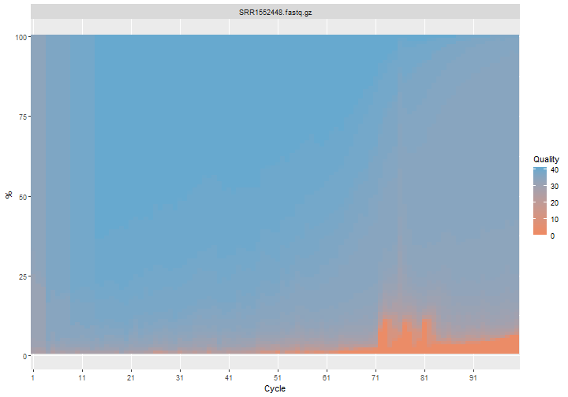

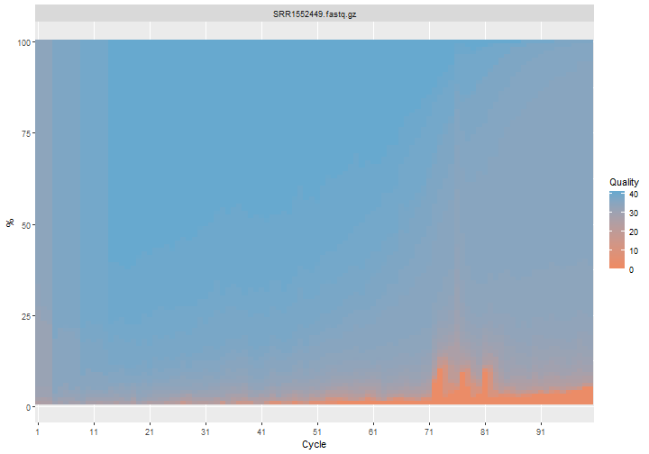

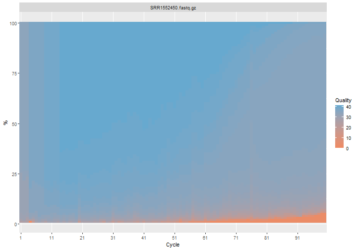

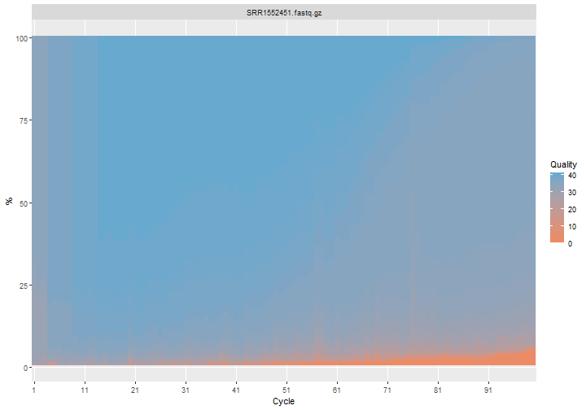

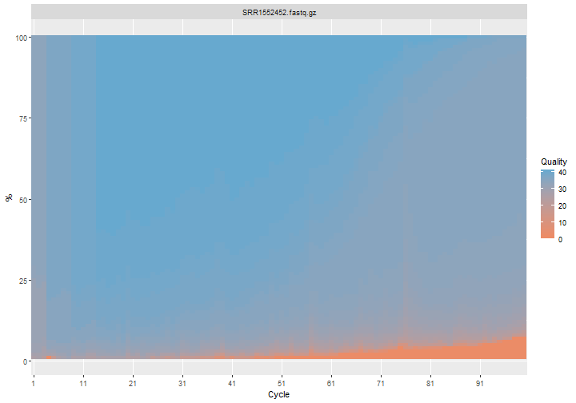

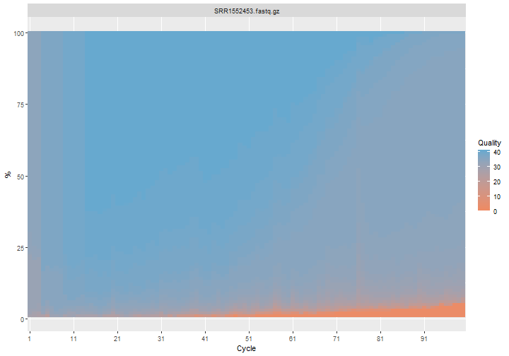

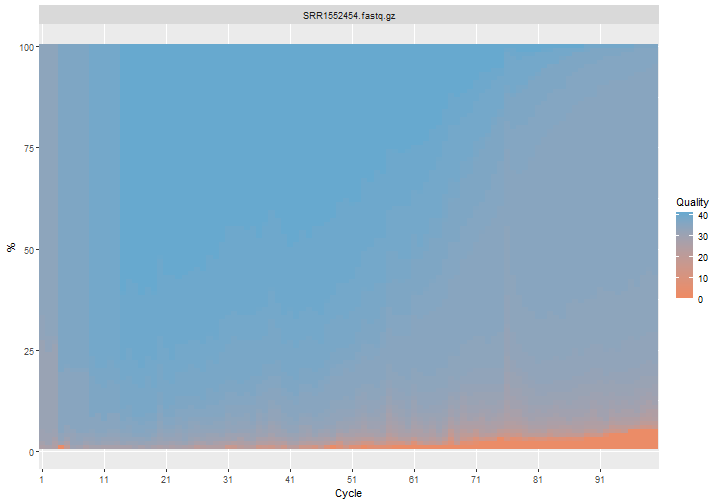

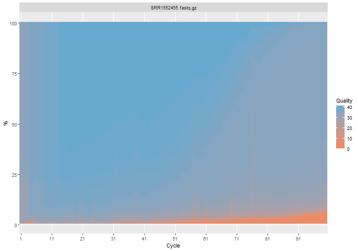

```r
for(pair in pairs) {
  rqcResultSet.sub <- subsetByPair(rqcResultSet, pair)
  print(rqcCycleQualityPlot(rqcResultSet.sub))
}
```